# Regression for Prediction Listing Price

Chawdhari,Khandalikar

April 24, 2018

**Load packages**

```r
library(readr)
library(caret)
library(xgboost)
library(dplyr)
```

**Loading the saved dataframe from visualization**

```
## 'data.frame':    5206 obs. of  157 variables:
##  $ id                                        : int  13824783 16740225 18125245 8362570 789867 16701336 8148031 6713059 17620535 12581064 ...
##  $ name                                      : Factor w/ 5169 levels "","(01A) Apartment Steps From Chicago's Grant Park",..: 2083 2293 1692 2759 1624 3065 3930 3871 4395 1928 ...
##  $ host_id                                   : int  55020055 36722941 51669215 32837114 2782694 36722941 43018961 2441740 756599 23503681 ...
##  $ host_name                                 : Factor w/ 1790 levels "5 Star Resorts Plus",..: 1441 418 1679 683 284 418 1392 928 1356 589 ...
##  $ host_since                                : Date, format: "2016-01-17" "2015-06-25" ...
##  $ host_response_time                        : Factor w/ 5 levels "","a few days or more",..: 5 5 5 4 5 5 5 1 5 5 ...
##  $ host_response_rate                        : num  100 100 100 100 100 ...
##  $ host_is_superhost                         : int  1 0 0 1 0 0 0 0 0 1 ...
##  $ host_listings_count                       : int  1 3 1 1 1 3 1 1 1 2 ...
##  $ host_total_listings_count                 : int  1 3 1 1 1 3 1 1 1 2 ...
##  $ host_verifications                        : Factor w/ 229 levels "[]","['email', 'facebook', 'reviews', 'jumio']",..: 91 201 188 91 51 201 122 199 93 138 ...
##  $ host_identity_verified                    : int  1 1 1 1 1 1 1 1 1 1 ...
##  $ street                                    : Factor w/ 268 levels "Albany Park, Chicago, IL 60618, United States",..: 154 65 154 154 155 154 155 65 65 154 ...
##  $ neighbourhood_cleansed                    : Factor w/ 72 levels "Albany Park",..: 36 36 36 36 36 36 36 36 36 36 ...
```

[output cut: 86 more lines]

**Patitioning Data into 70% train and 30%test**

```r
set.seed(1828)
sample_size <- ceiling(0.30 * nrow(dflistings))
testrecs <- sample(nrow(dflistings),sample_size)
test_data <- dflistings[testrecs,]
train_data <- dflistings[-testrecs,]
rm(dflistings)
```

```r
#verify data structure

str(train_data)
```

```
## 'data.frame':    3644 obs. of  157 variables:
##  $ id                                        : int  13824783 16740225 789867 16701336 8148031 17620535 12581064 8764277 14669492 11034368 ...
##  $ name                                      : Factor w/ 5169 levels "","(01A) Apartment Steps From Chicago's Grant Park",..: 2083 2293 1624 3065 3930 4395 1928 2697 2862 1720 ...
##  $ host_id                                   : int  55020055 36722941 2782694 36722941 43018961 756599 23503681 40622810 13222552 36392340 ...
##  $ host_name                                 : Factor w/ 1790 levels "5 Star Resorts Plus",..: 1441 418 284 418 1392 1356 589 1031 280 711 ...
##  $ host_since                                : Date, format: "2016-01-17" "2015-06-25" ...
##  $ host_response_time                        : Factor w/ 5 levels "","a few days or more",..: 5 5 5 5 5 5 5 5 5 4 ...
##  $ host_response_rate                        : num  100 100 100 100 100 100 100 100 100 100 ...
##  $ host_is_superhost                         : int  1 0 0 0 0 0 1 0 0 0 ...
##  $ host_listings_count                       : int  1 3 1 3 1 1 2 1 2 1 ...
##  $ host_total_listings_count                 : int  1 3 1 3 1 1 2 1 2 1 ...
##  $ host_verifications                        : Factor w/ 229 levels "[]","['email', 'facebook', 'reviews', 'jumio']",..: 91 201 51 201 122 93 138 199 157 201 ...
##  $ host_identity_verified                    : int  1 1 1 1 1 1 1 1 1 1 ...
##  $ street                                    : Factor w/ 268 levels "Albany Park, Chicago, IL 60618, United States",..: 154 65 155 154 155 65 154 154 65 100 ...
##  $ neighbourhood_cleansed                    : Factor w/ 72 levels "Albany Park",..: 36 36 36 36 36 36 36 36 36 36 ...
```

[output cut: 86 more lines]

```r
str(test_data)
```

```
## 'data.frame':    1562 obs. of  157 variables:
##  $ id                                        : int  14990081 18139782 13531342 15250951 17843825 3857383 14553446 12891430 984850 13209954 ...
##  $ name                                      : Factor w/ 5169 levels "","(01A) Apartment Steps From Chicago's Grant Park",..: 4804 3667 3774 3931 2981 4217 5013 3549 309 899 ...
##  $ host_id                                   : int  7385019 22308676 35412645 20538405 120753561 14554282 42771477 70408181 5402236 10845941 ...
##  $ host_name                                 : Factor w/ 1790 levels "5 Star Resorts Plus",..: 453 269 182 193 1658 858 1553 1236 1181 68 ...
##  $ host_since                                : Date, format: "2013-07-09" "2014-10-08" ...
##  $ host_response_time                        : Factor w/ 5 levels "","a few days or more",..: 4 5 5 5 5 1 5 5 5 5 ...
##  $ host_response_rate                        : num  90 100 100 100 100 ...
##  $ host_is_superhost                         : int  0 0 0 0 0 0 0 0 1 0 ...
##  $ host_listings_count                       : int  1 2 6 2 1 1 1 3 4 1 ...
##  $ host_total_listings_count                 : int  1 2 6 2 1 1 1 3 4 1 ...
##  $ host_verifications                        : Factor w/ 229 levels "[]","['email', 'facebook', 'reviews', 'jumio']",..: 131 166 38 209 80 13 199 113 180 199 ...
##  $ host_identity_verified                    : int  1 1 1 0 1 1 1 1 1 1 ...
##  $ street                                    : Factor w/ 268 levels "Albany Park, Chicago, IL 60618, United States",..: 135 85 124 134 154 129 159 157 202 140 ...
##  $ neighbourhood_cleansed                    : Factor w/ 72 levels "Albany Park",..: 31 29 26 30 36 71 46 46 44 33 ...
```

[output cut: 86 more lines]

**Model Fitting- Linear Regression**

Based on the EDA and some logical thinking we came up with a few variables that we thought would help explaining the variability in price ,and thus be useful for price predition. We started with fitting all the variables we thought might be useful

```r
# With Price on a normal scale and variables selected from the eda


LM1 <- lm(price ~ neighbourhood_cleansed + property_type +train_data$accommodates + train_data$number_of_reviews +train_data$availability_365 +train_data$instant_bookable  + train_data$cancellation_policy + train_data$bathrooms + train_data$beds, data=train_data)
summary(LM1)
```

```
##
## Call:
## lm(formula = price ~ neighbourhood_cleansed + property_type +
##     train_data$accommodates + train_data$number_of_reviews +
##     train_data$availability_365 + train_data$instant_bookable +
##     train_data$cancellation_policy + train_data$bathrooms + train_data$beds,
##     data = train_data)
##
## Residuals:
##    Min     1Q Median     3Q    Max
## -739.5  -44.0   -7.9   25.6 4721.3
##
## Coefficients:
##                                                 Estimate Std. Error
## (Intercept)                                    -60.53706   34.24662
## neighbourhood_cleansedArcher Heights            -4.83019  113.48013
## neighbourhood_cleansedArmour Square            -10.42146   41.87282
## neighbourhood_cleansedAshburn                  -28.12236  113.33743
## neighbourhood_cleansedAuburn Gresham           -21.51021  113.29820
## neighbourhood_cleansedAustin                    -1.92394   55.49750
## neighbourhood_cleansedAvondale                  -8.40726   36.55692
## neighbourhood_cleansedBelmont Cragin           -14.61998   54.30119
## neighbourhood_cleansedBeverly                    7.99264  113.33720
## neighbourhood_cleansedBridgeport                 4.71334   42.07389
## neighbourhood_cleansedBrighton Park            -14.14591  113.29523
## neighbourhood_cleansedCalumet Heights          -43.88174  156.75083
## neighbourhood_cleansedChatham                   87.41515  156.68273
## neighbourhood_cleansedChicago Lawn               6.32563  156.59689
## neighbourhood_cleansedClearing                  29.80240  156.72687
## neighbourhood_cleansedDouglas                    9.73866   41.51583
## neighbourhood_cleansedDunning                  -39.15513   71.03218
## neighbourhood_cleansedEast Garfield Park       -66.49276   41.63159
## neighbourhood_cleansedEdgewater                 22.99110   36.40167
## neighbourhood_cleansedEdison Park             -101.92128  113.44714
## neighbourhood_cleansedEnglewood                -17.39303   61.13378
## neighbourhood_cleansedForest Glen               18.65604   63.73062
## neighbourhood_cleansedFuller Park              -38.86838   55.67483
## neighbourhood_cleansedGarfield Ridge           -60.45860  113.44797
## neighbourhood_cleansedGrand Boulevard          -14.07989   40.98441
## neighbourhood_cleansedGreater Grand Crossing    -8.12730   54.16188
```

[output cut: 128 more lines]

```
## train_data$accommodates                        12.748  < 2e-16 ***
## train_data$number_of_reviews                   -5.231 1.79e-07 ***
## train_data$availability_365                     3.590 0.000335 ***
## train_data$instant_bookable                    -3.285 0.001030 **
## train_data$cancellation_policymoderate         -0.150 0.880570
## train_data$cancellation_policystrict           -1.215 0.224409
## train_data$cancellation_policysuper_strict_30   0.387 0.698929
## train_data$bathrooms                           12.876  < 2e-16 ***
## train_data$beds                                -1.326 0.184784
## ---
## Signif. codes:  0 '***' 0.001 '**' 0.01 '*' 0.05 '.' 0.1 ' ' 1
##
## Residual standard error: 152.9 on 3563 degrees of freedom
## Multiple R-squared:  0.2747, Adjusted R-squared:  0.2584
## F-statistic: 16.87 on 80 and 3563 DF,  p-value: < 2.2e-16
```

```r
median(abs(LM1$residuals))
```

```
## [1] 34.20491
```

The results from first fit were not good at all ,with a very low Rsquared and a high MAD!!!! Hence,we tried to use price on a log scale (because the price range was huge and log would help notice the smaller changes in price )

```r
#Change price to Log scale


summary(train_data$price)
```

```
##    Min. 1st Qu.  Median    Mean 3rd Qu.    Max.
##     0.0    64.0   100.0   137.2   159.0  5000.0
```

```r
#Converting price to log scale
train_data$logprice <- log(train_data$price)

#Check for na and infs
sum(is.infinite(train_data$logprice))
```

```
## [1] 1
```

```r
length(train_data$logprice[is.na(train_data$logprice)])
```

```
## [1] 0
```

```r
#replace inf for price with 0
train_data$logprice[is.infinite(train_data$logprice)] <- 0
```

Model 2.Using Log price as the dependent variable

```r
LM2 <- lm(logprice ~ neighbourhood_cleansed + property_type  +train_data$accommodates + train_data$number_of_reviews + train_data$instant_bookable  + train_data$cancellation_policy + train_data$bathrooms + train_data$beds, data=train_data)

median(abs(LM2$residuals))
```

```
## [1] 0.2953258
```

```r
summary(LM2)
```

```
##
## Call:
## lm(formula = logprice ~ neighbourhood_cleansed + property_type +
##     train_data$accommodates + train_data$number_of_reviews +
##     train_data$instant_bookable + train_data$cancellation_policy +
##     train_data$bathrooms + train_data$beds, data = train_data)
##
## Residuals:
##     Min      1Q  Median      3Q     Max
## -4.8724 -0.2874  0.0100  0.3015  3.2615
##
## Coefficients:
##                                                 Estimate Std. Error
## (Intercept)                                    3.7112224  0.1119387
## neighbourhood_cleansedArcher Heights          -0.5387177  0.3715468
## neighbourhood_cleansedArmour Square           -0.0650011  0.1370111
## neighbourhood_cleansedAshburn                 -0.4282864  0.3710660
## neighbourhood_cleansedAuburn Gresham          -0.1142691  0.3706511
## neighbourhood_cleansedAustin                   0.0739979  0.1815908
## neighbourhood_cleansedAvondale                -0.1330003  0.1196745
## neighbourhood_cleansedBelmont Cragin          -0.2630728  0.1774341
## neighbourhood_cleansedBeverly                  0.1359374  0.3710585
## neighbourhood_cleansedBridgeport              -0.0291253  0.1376628
## neighbourhood_cleansedBrighton Park           -0.1751602  0.3709357
## neighbourhood_cleansedCalumet Heights         -0.0786418  0.5131948
## neighbourhood_cleansedChatham                  1.0890578  0.5129899
## neighbourhood_cleansedChicago Lawn            -0.2731052  0.5127056
## neighbourhood_cleansedClearing                 0.1670107  0.5131408
## neighbourhood_cleansedDouglas                  0.0879270  0.1357822
## neighbourhood_cleansedDunning                  0.0204262  0.2324870
## neighbourhood_cleansedEast Garfield Park      -0.3882502  0.1362197
## neighbourhood_cleansedEdgewater                0.2257840  0.1191534
## neighbourhood_cleansedEdison Park             -0.0658141  0.3714389
## neighbourhood_cleansedEnglewood               -0.8277222  0.2001580
## neighbourhood_cleansedForest Glen              0.2210945  0.2085997
## neighbourhood_cleansedFuller Park             -0.4043570  0.1817704
## neighbourhood_cleansedGarfield Ridge          -0.4597337  0.3714323
## neighbourhood_cleansedGrand Boulevard         -0.0408844  0.1340945
## neighbourhood_cleansedGreater Grand Crossing  -0.4999660  0.1772970
## neighbourhood_cleansedHegewisch                0.6619661  0.5131728
```

[output cut: 125 more lines]

```
## property_typeOthers                             2.353  0.01868 *
## train_data$accommodates                        23.889  < 2e-16 ***
## train_data$number_of_reviews                   -7.728 1.41e-14 ***
## train_data$instant_bookable                    -6.702 2.38e-11 ***
## train_data$cancellation_policymoderate          3.252  0.00116 **
## train_data$cancellation_policystrict            1.551  0.12106
## train_data$cancellation_policysuper_strict_30   0.825  0.40964
## train_data$bathrooms                            8.303  < 2e-16 ***
## train_data$beds                                 0.054  0.95706
## ---
## Signif. codes:  0 '***' 0.001 '**' 0.01 '*' 0.05 '.' 0.1 ' ' 1
##
## Residual standard error: 0.5005 on 3564 degrees of freedom
## Multiple R-squared:  0.5308, Adjusted R-squared:  0.5204
## F-statistic: 51.03 on 79 and 3564 DF,  p-value: < 2.2e-16
```

**Some more variation with combination of different variables**

*Adding Active length of the listing*

Adding the lenght of Active days in the model did improve it a little !!

```r
#removing a few insignificant

LM2 <- lm(logprice ~ neighbourhood_cleansed + property_type + accommodates + number_of_reviews + bathrooms + ActiveDays + host_response_time , data=train_data)

median(abs(LM2$residuals))
```

```
## [1] 0.2876718
```

```r
summary(LM2)
```

```
##
## Call:
## lm(formula = logprice ~ neighbourhood_cleansed + property_type +
##     accommodates + number_of_reviews + bathrooms + ActiveDays +
##     host_response_time, data = train_data)
##
## Residuals:
##     Min      1Q  Median      3Q     Max
## -4.8958 -0.2835  0.0082  0.2921  3.2103
##
## Coefficients:
##                                                Estimate Std. Error t value
## (Intercept)                                   3.818e+00  1.142e-01  33.416
## neighbourhood_cleansedArcher Heights         -5.528e-01  3.683e-01  -1.501
## neighbourhood_cleansedArmour Square          -6.522e-03  1.362e-01  -0.048
## neighbourhood_cleansedAshburn                -3.177e-01  3.683e-01  -0.863
## neighbourhood_cleansedAuburn Gresham         -8.395e-02  3.678e-01  -0.228
## neighbourhood_cleansedAustin                  8.210e-02  1.801e-01   0.456
## neighbourhood_cleansedAvondale               -1.103e-01  1.188e-01  -0.928
## neighbourhood_cleansedBelmont Cragin         -2.295e-01  1.763e-01  -1.302
## neighbourhood_cleansedBeverly                 1.214e-01  3.684e-01   0.330
## neighbourhood_cleansedBridgeport              1.668e-02  1.368e-01   0.122
## neighbourhood_cleansedBrighton Park          -1.368e-01  3.679e-01  -0.372
## neighbourhood_cleansedCalumet Heights         1.061e-02  5.090e-01   0.021
## neighbourhood_cleansedChatham                 9.930e-01  5.095e-01   1.949
## neighbourhood_cleansedChicago Lawn           -3.150e-01  5.087e-01  -0.619
## neighbourhood_cleansedClearing                2.414e-01  5.089e-01   0.474
## neighbourhood_cleansedDouglas                 1.506e-01  1.350e-01   1.115
## neighbourhood_cleansedDunning                 1.533e-02  2.308e-01   0.066
## neighbourhood_cleansedEast Garfield Park     -3.357e-01  1.354e-01  -2.480
## neighbourhood_cleansedEdgewater               2.611e-01  1.183e-01   2.207
## neighbourhood_cleansedEdison Park            -3.775e-02  3.686e-01  -0.102
## neighbourhood_cleansedEnglewood              -8.589e-01  1.982e-01  -4.334
## neighbourhood_cleansedForest Glen             1.227e-01  2.071e-01   0.592
## neighbourhood_cleansedFuller Park            -3.738e-01  1.810e-01  -2.065
## neighbourhood_cleansedGarfield Ridge         -3.235e-01  3.684e-01  -0.878
## neighbourhood_cleansedGrand Boulevard        -1.136e-02  1.331e-01  -0.085
## neighbourhood_cleansedGreater Grand Crossing -4.855e-01  1.758e-01  -2.762
## neighbourhood_cleansedHegewisch               5.666e-01  5.090e-01   1.113
## neighbourhood_cleansedHermosa                -3.686e-01  2.475e-01  -1.489
```

[output cut: 124 more lines]

```
## property_typeOthers                          0.020439 *
## accommodates                                  < 2e-16 ***
## number_of_reviews                            4.01e-15 ***
## bathrooms                                    5.14e-16 ***
## ActiveDays                                   8.24e-07 ***
## host_response_timea few days or more         0.532349
## host_response_timewithin a day               0.125211
## host_response_timewithin a few hours         0.005185 **
## host_response_timewithin an hour             3.98e-09 ***
## ---
## Signif. codes:  0 '***' 0.001 '**' 0.01 '*' 0.05 '.' 0.1 ' ' 1
##
## Residual standard error: 0.4965 on 3564 degrees of freedom
## Multiple R-squared:  0.5382, Adjusted R-squared:  0.528
## F-statistic: 52.58 on 79 and 3564 DF,  p-value: < 2.2e-16
```

**Adding Room Type**

Adding back RoomType to the model worked really well !!!

```r
LM3 <- lm(logprice ~  neighbourhood_cleansed +  property_type + accommodates + number_of_reviews + room_type + bathrooms + ActiveDays + host_response_time, data=train_data)

median(abs(LM3$residuals))
```

```
## [1] 0.2370499
```

```r
summary(LM3)
```

```
##
## Call:
## lm(formula = logprice ~ neighbourhood_cleansed + property_type +
##     accommodates + number_of_reviews + room_type + bathrooms +
##     ActiveDays + host_response_time, data = train_data)
##
## Residuals:
##     Min      1Q  Median      3Q     Max
## -5.0122 -0.2398 -0.0040  0.2344  3.1223
##
## Coefficients:
##                                                Estimate Std. Error t value
## (Intercept)                                   4.143e+00  1.033e-01  40.108
## neighbourhood_cleansedArcher Heights         -4.165e-01  3.303e-01  -1.261
## neighbourhood_cleansedArmour Square           1.395e-01  1.223e-01   1.141
## neighbourhood_cleansedAshburn                -1.746e-01  3.303e-01  -0.529
## neighbourhood_cleansedAuburn Gresham          1.271e-01  3.299e-01   0.385
## neighbourhood_cleansedAustin                  6.116e-02  1.615e-01   0.379
## neighbourhood_cleansedAvondale               -2.876e-02  1.066e-01  -0.270
## neighbourhood_cleansedBelmont Cragin         -6.039e-02  1.582e-01  -0.382
## neighbourhood_cleansedBeverly                 4.197e-02  3.303e-01   0.127
## neighbourhood_cleansedBridgeport              8.664e-02  1.227e-01   0.706
## neighbourhood_cleansedBrighton Park          -2.747e-01  3.299e-01  -0.833
## neighbourhood_cleansedCalumet Heights         3.203e-01  4.565e-01   0.702
## neighbourhood_cleansedChatham                 5.800e-01  4.571e-01   1.269
## neighbourhood_cleansedChicago Lawn           -7.618e-02  4.562e-01  -0.167
## neighbourhood_cleansedClearing                3.286e-01  4.563e-01   0.720
## neighbourhood_cleansedDouglas                 1.611e-01  1.211e-01   1.331
## neighbourhood_cleansedDunning                 3.183e-02  2.070e-01   0.154
## neighbourhood_cleansedEast Garfield Park     -2.671e-01  1.214e-01  -2.200
## neighbourhood_cleansedEdgewater               2.372e-01  1.061e-01   2.236
## neighbourhood_cleansedEdison Park            -1.434e-01  3.305e-01  -0.434
## neighbourhood_cleansedEnglewood              -4.865e-01  1.788e-01  -2.721
## neighbourhood_cleansedForest Glen             1.470e-01  1.857e-01   0.791
## neighbourhood_cleansedFuller Park            -2.110e-01  1.624e-01  -1.299
## neighbourhood_cleansedGarfield Ridge         -3.164e-01  3.303e-01  -0.958
## neighbourhood_cleansedGrand Boulevard         4.225e-02  1.194e-01   0.354
## neighbourhood_cleansedGreater Grand Crossing -3.850e-01  1.577e-01  -2.441
## neighbourhood_cleansedHegewisch               1.847e-01  4.567e-01   0.404
## neighbourhood_cleansedHermosa                -2.938e-01  2.219e-01  -1.324
```

[output cut: 128 more lines]

```
## number_of_reviews                            1.95e-15 ***
## room_typePrivate room                         < 2e-16 ***
## room_typeShared room                          < 2e-16 ***
## bathrooms                                     < 2e-16 ***
## ActiveDays                                   9.30e-07 ***
## host_response_timea few days or more         0.637781
## host_response_timewithin a day               0.310419
## host_response_timewithin a few hours         0.002686 **
## host_response_timewithin an hour             6.52e-09 ***
## ---
## Signif. codes:  0 '***' 0.001 '**' 0.01 '*' 0.05 '.' 0.1 ' ' 1
##
## Residual standard error: 0.4452 on 3562 degrees of freedom
## Multiple R-squared:  0.6289, Adjusted R-squared:  0.6205
## F-statistic: 74.53 on 81 and 3562 DF,  p-value: < 2.2e-16
```

**Prediction of TrainData**

Since the Model3 had the best MAD and Rsquare we decided to go with Model this for further predictions !!!

```r
TrainPredictM3 <- predict(LM3, newdata= train_data, se.fit=TRUE,
                         interval="prediction", level=0.95)

predicted_train <- data.frame(TrainPredict = TrainPredictM3$fit[,1],
                                TrainActual = train_data$logprice)
```

**Scatter Plot Actual vs Predicted and Normality Test**

The scatter plot shows a diagonal patter ,which seems like the model is a good fit. Also,normality could be verifies using anderson normality test,with a very smaller p value rejecting the null hypothesis that the data is normally distributed.

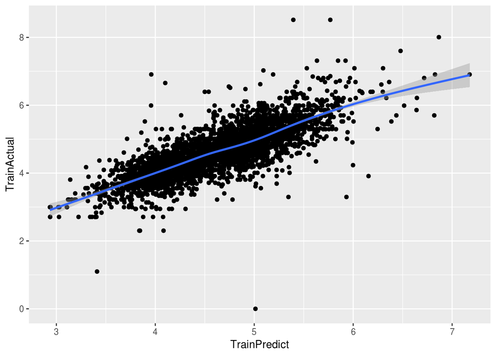

```r
ggplot(predicted_train,aes(x= TrainPredict, y = TrainActual)) + geom_point() + geom_smooth()
```

```r
library('nortest')
ad.test(LM3$residuals)
```

```
##
##  Anderson-Darling normality test
##
## data:  LM3$residuals
## A = 21.778, p-value < 2.2e-16
```

**Predictions on Test Data**

```r
# removed a few levels that were not present in the train data and gave errors while predicting on tes
#There sure could have been a better solution than this !

test_data <- test_data %>% filter(neighbourhood_cleansed != 'Montclare' & neighbourhood_cleansed !='Mount Greenwood' & neighbourhood_cleansed != 'Washington Heights')


test_data$logprice <- log(test_data$price)

test_data$logprice[is.infinite(test_data$logprice)] <- 0


LM3Predicttest <- predict(LM3, newdata= test_data, se.fit=TRUE,
                         interval="prediction", level=0.95)



madtest<- median(abs(test_data$logprice - LM3Predicttest$fit[,1]))

madtrain<-median(abs(LM3$residuals))

Model <- c('TrainMAD','TestMAD')

Mads <- c(madtrain,madtest)

MadSummary <- data.frame(Model,Mads)

print(MadSummary)
```

```
##      Model      Mads
## 1 TrainMAD 0.2370499
## 2  TestMAD 0.2551830
```

For Linear regression The MAD on test was 0.25.The train data predicted the price more accurately than the test data. The MAD increased by 0.02 from train to test

**Xgboost**

We also tried to use Xgboost to predict prices we refered a couple of online sources and videos to implement the Xgboost Model

```r
fiveStats = function(...) c (defaultSummary(...))
ctrl <- trainControl(method = "cv", #  cross validation
number = 10, # 10 fold
summaryFunction=fiveStats,
classProbs=FALSE,
savePredictions=T,
allowParallel = TRUE)



xgb.grid <- expand.grid(nrounds = 500,
eta = c(0.01,0.1),
colsample_bytree =1,
gamma=0.8,
min_child_weight=1,
subsample=1,
max_depth = c(2,6,10))

trainXGB <- na.omit(train_data %>% select(price,logprice,neighbourhood_cleansed,property_type,accommodates,number_of_reviews,room_type,bathrooms,ActiveDays,host_response_time,logprice)
)

testXGB <- na.omit(test_data %>% select(price,logprice,neighbourhood_cleansed,property_type,accommodates,number_of_reviews,room_type,bathrooms,ActiveDays,host_response_time)
)



#convert the data to numeric values
Numeric_trainXGB <- data.frame(data.matrix(trainXGB))
Numeric_TestXBG <- data.frame(data.matrix(testXGB))


#train model on traindata




set.seed(1234)
ModelXBG <-train(x=Numeric_trainXGB[,-2],y= Numeric_trainXGB$logprice,
booster ="gblinear",
method="xgbTree",
metric="RMSE",
trControl=ctrl,
tuneGrid=xgb.grid)
#results from Train
results <-ModelXBG$results


#Predict Prices for test data
test_preds <- predict(ModelXBG,Numeric_TestXBG)
median(abs(test_data$logprice - test_preds))
```

```
## [1] 0.2473527
```